# 20240820_HT_ATAC_paper

Authors

Matt Paul

Bioinformatics Resource Center

Rockefeller University

Published

August 29, 2024

3. If the integration has been finalized, provide the UMAP for snATAC-seq data of ARC and PVH. (Fig1), and the percentage of each cell type in the region from the snATAC-seq data (Fig.1f,g). Right now, we have snRNA-seq data for Fig.1f,g.

# ARC

## Full Dataset

UMAPs showing ATAC datasets. These grouped by the samples, basic clustering (based on the ATAC) and RNA clustering.

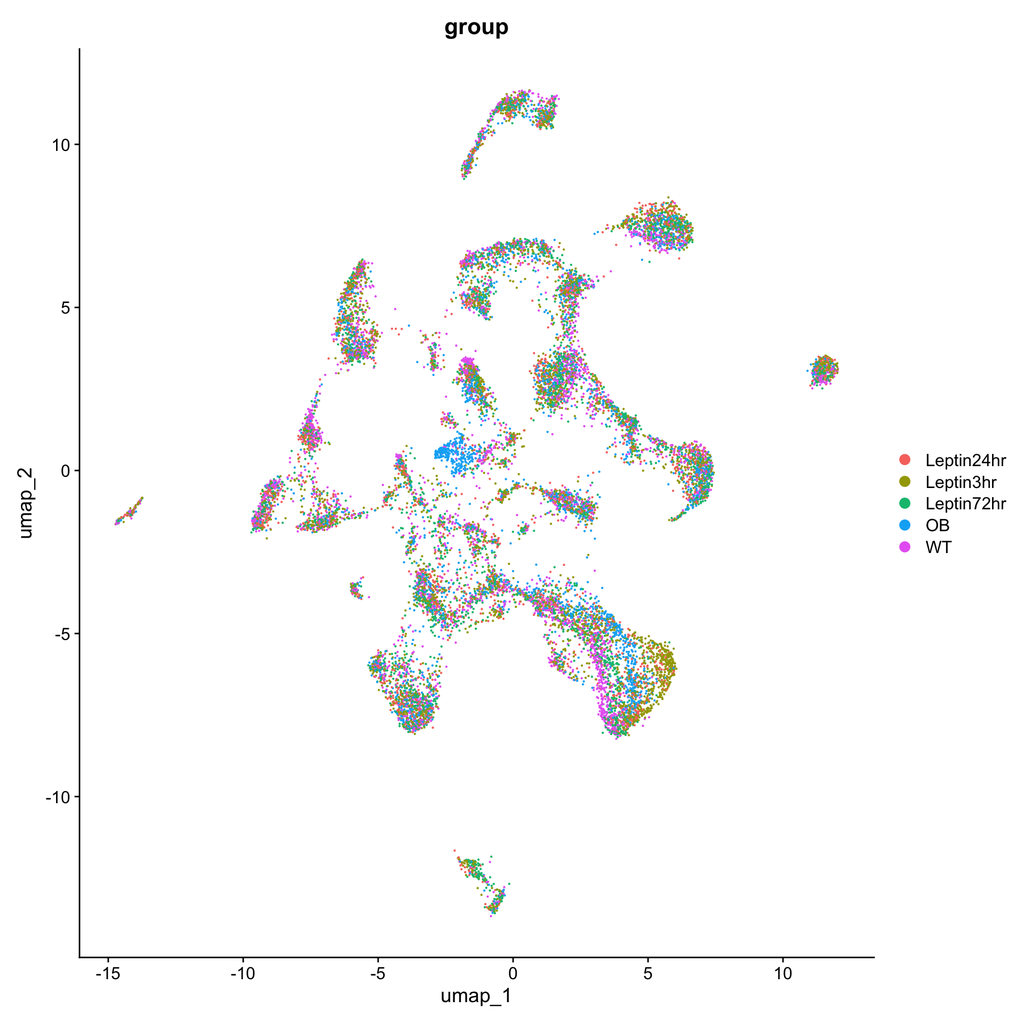

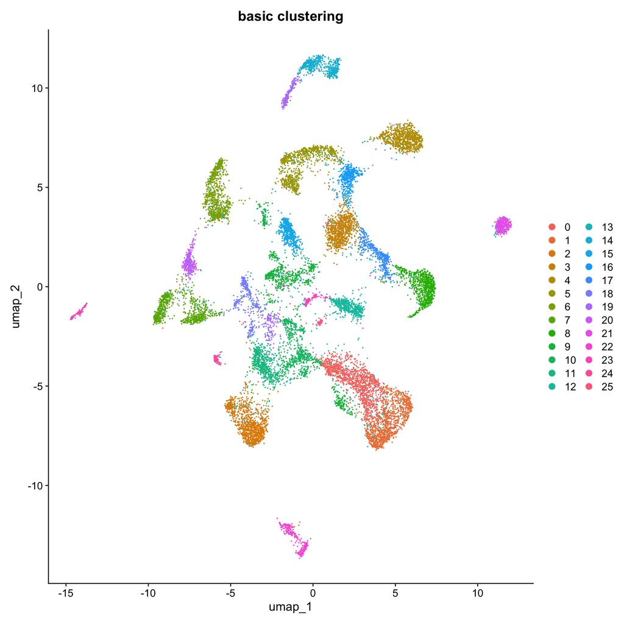

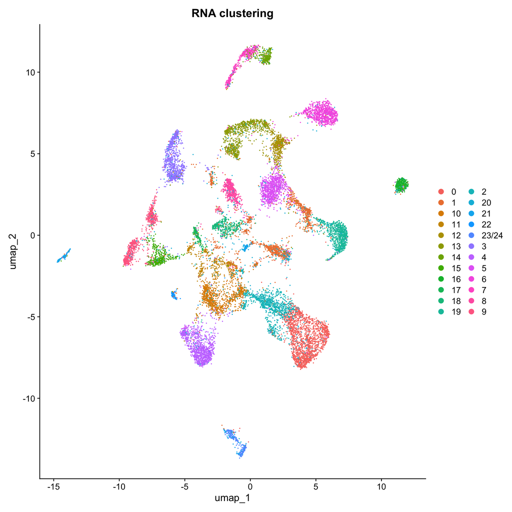

These are the proportions on the ATAc specific clusters.

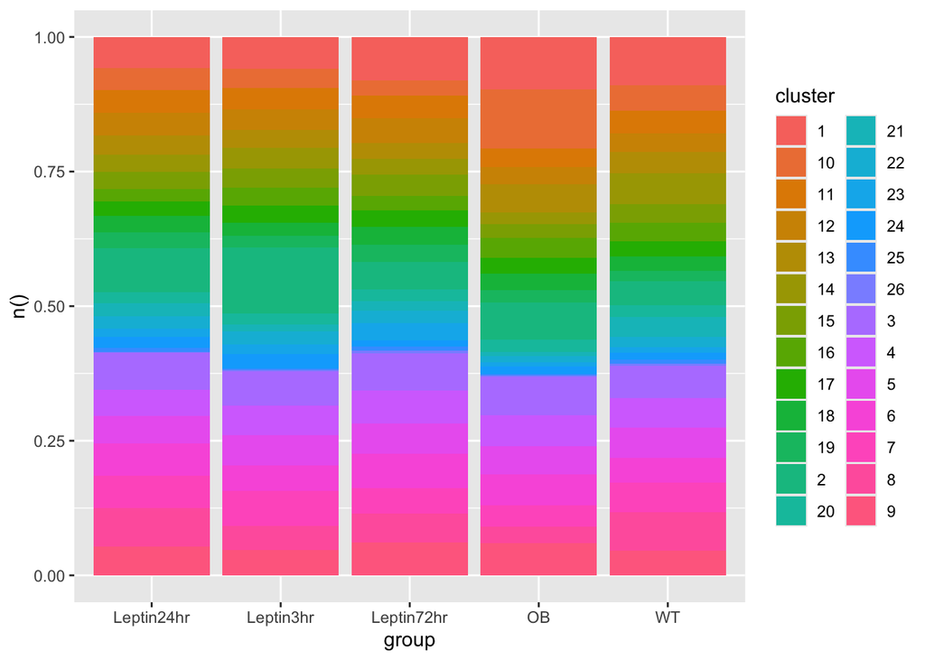

## RNA subset

UMAPs showing ATAC datasets. These grouped by the samples, basic clustering (based on the ATAC) and RNA clustering.

The dataset has been subset based on how the RNA has been subset.

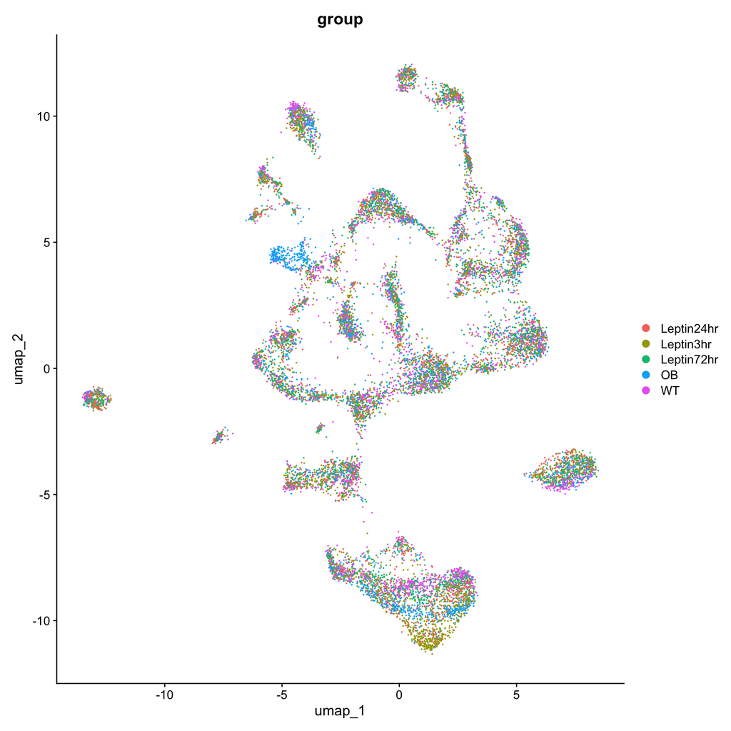

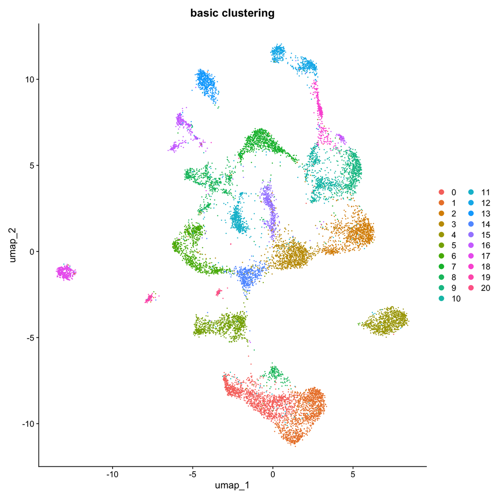

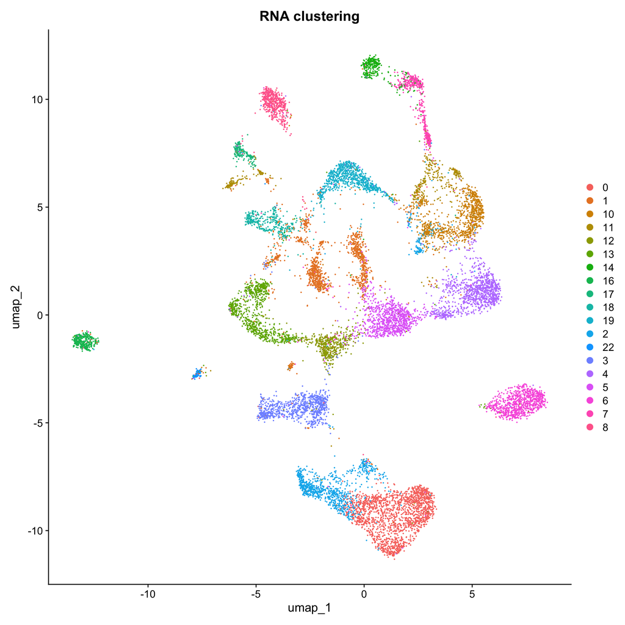

These are the proportions on the ATAC specific clusters.

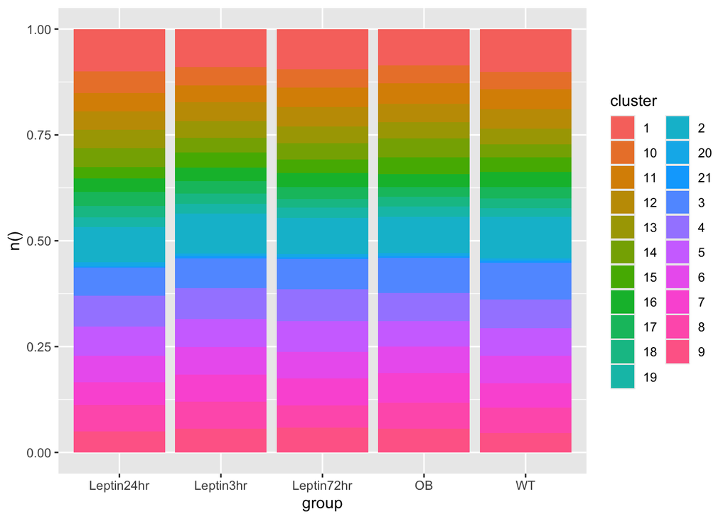

# PVH

## Full Dataset

UMAPs showing ATAC datasets. These grouped by the samples, basic clustering (based on the ATAC) and RNA clustering.

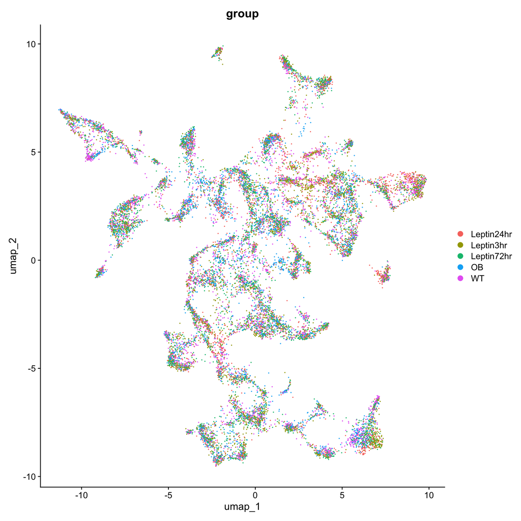

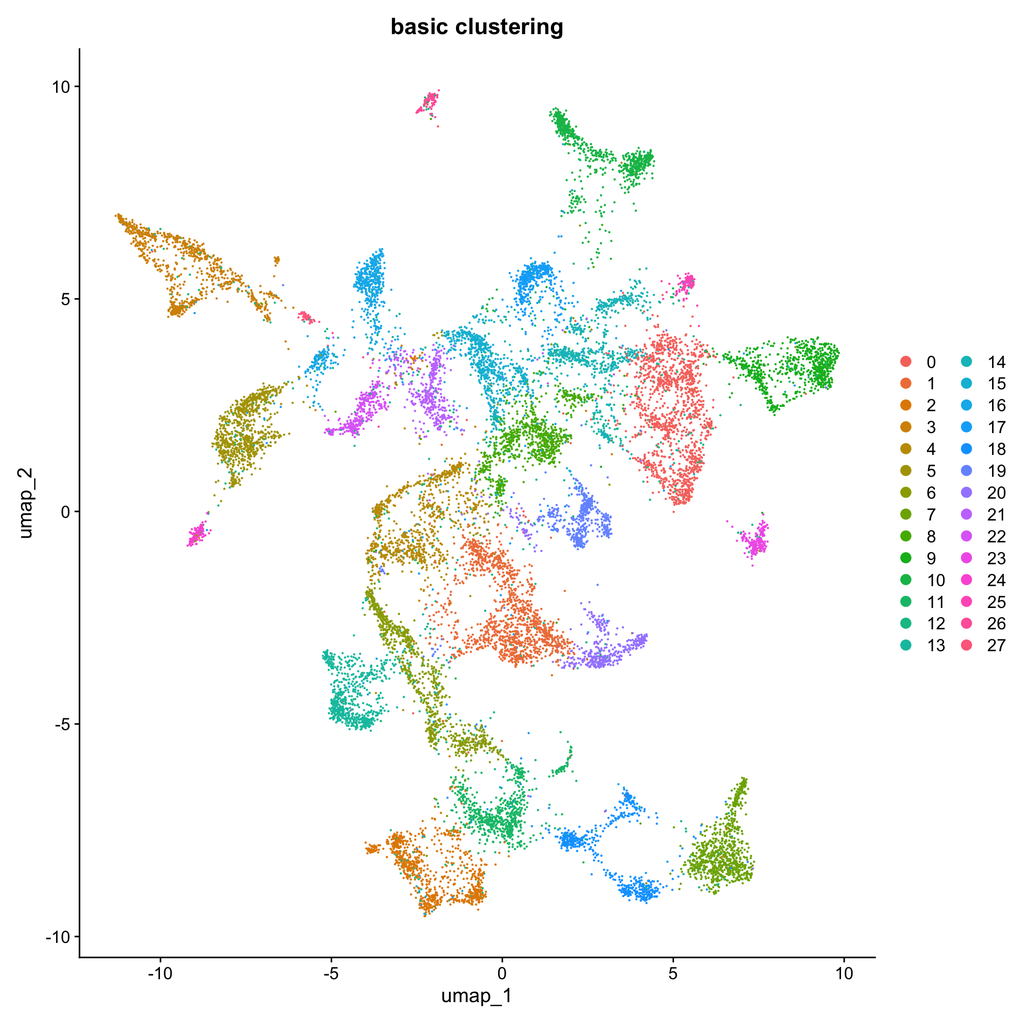

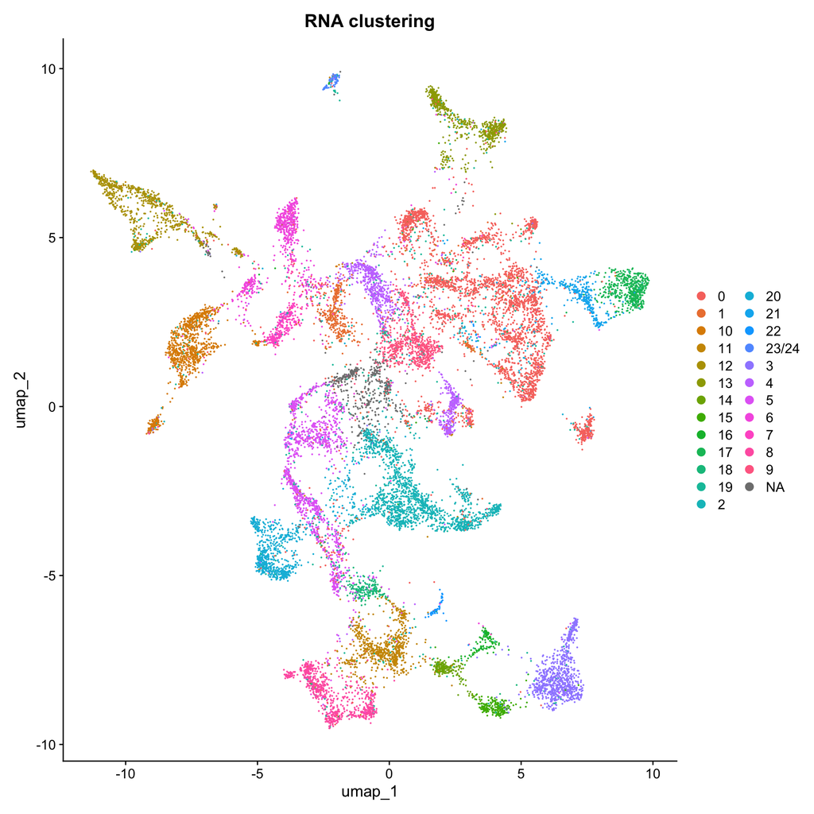

These are the proportions on the ATAC specific clusters.

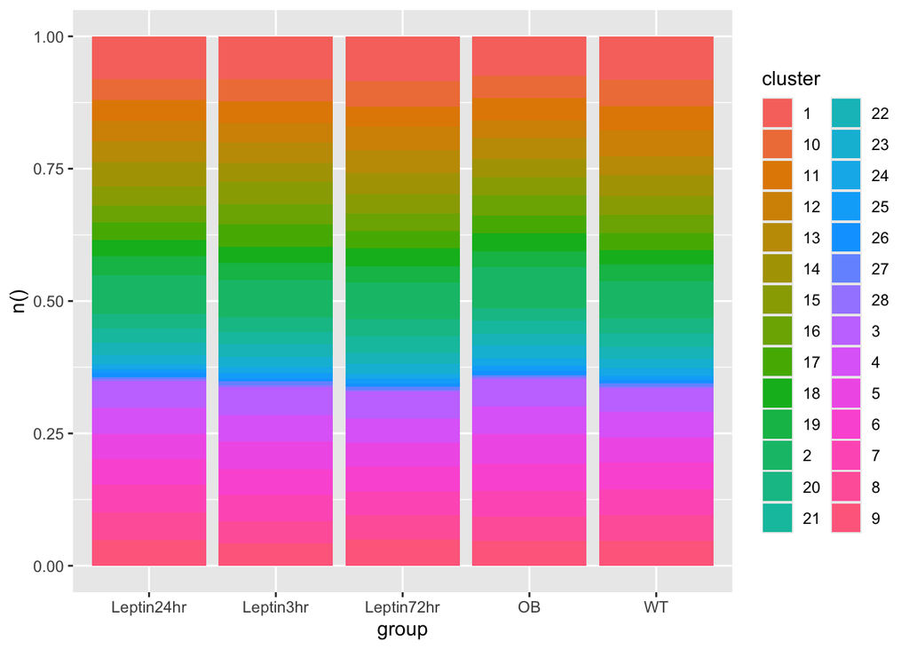

## RNA subset

UMAPs showing ATAC datasets. These grouped by the samples, basic clustering (based on the ATAC) and RNA clustering.

The dataset has been subset based on how the RNA has been subset.

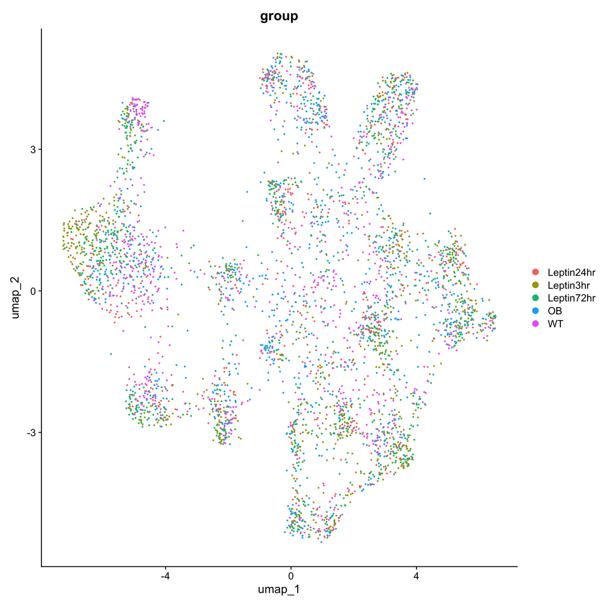

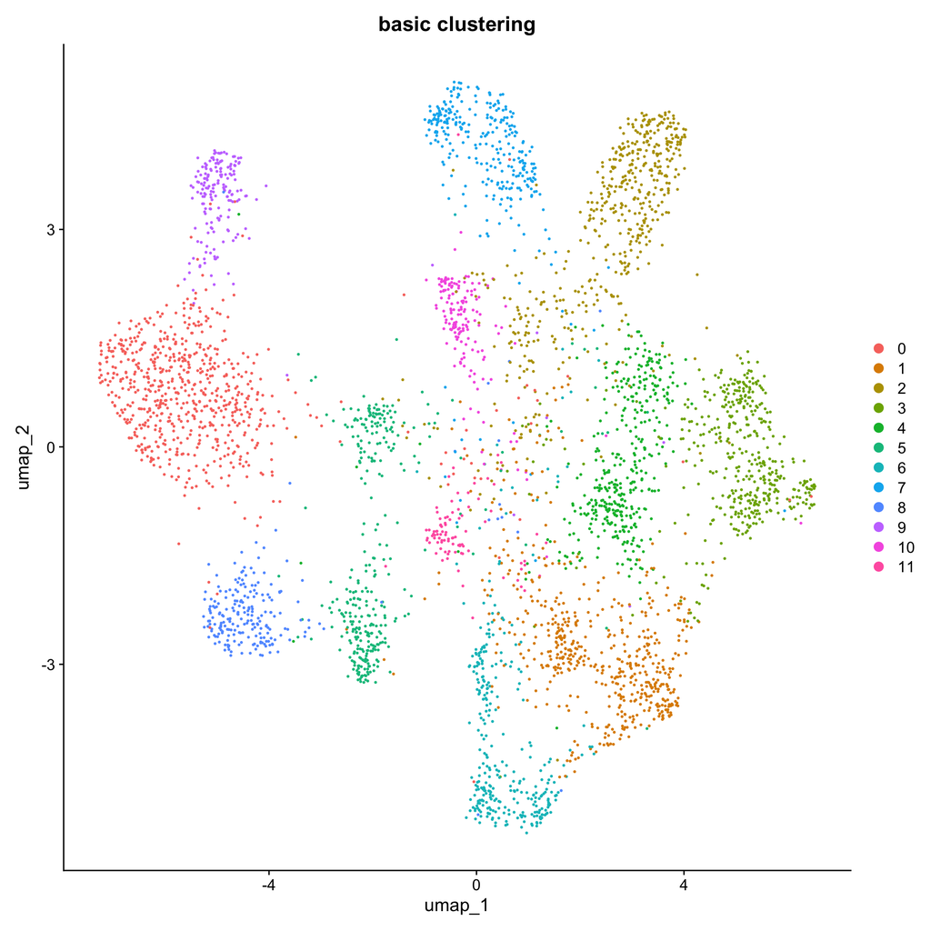

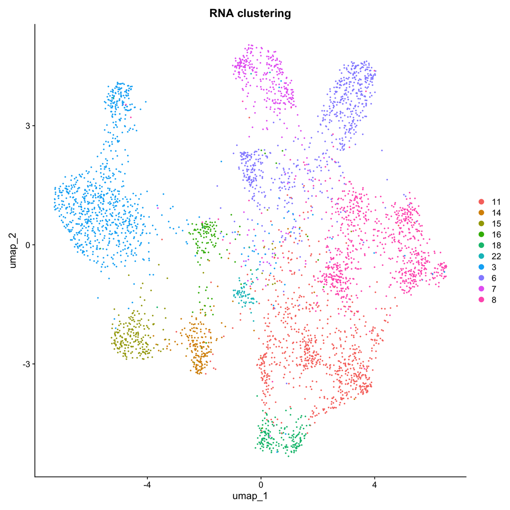

These are the proportions on the ATAC specific clusters.

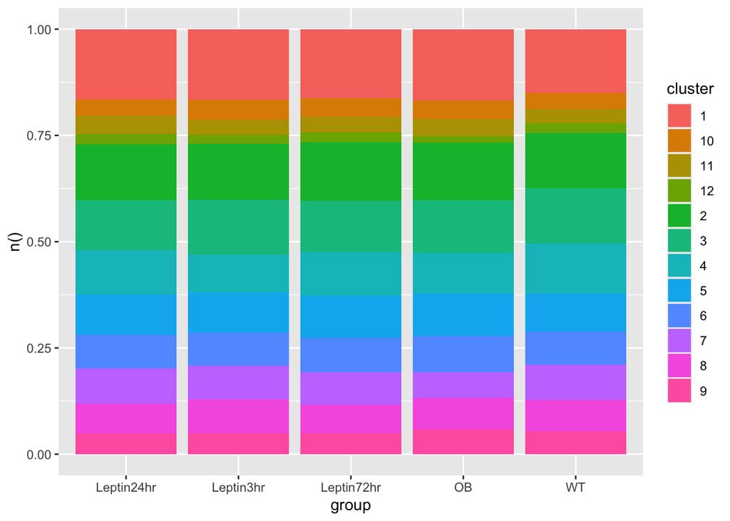